**Mauricio Montero**

[figure not shown]

# Preprocesamiento de Datos

## Indice de Contenido

- Manejo de variables categoricas
- EliminaciÃ³n de valores nulos
- Imputing
- Centering and scaling
- Pipelines utilizando Imputing y scaling:

## 1-Manejo de variables categóricas

En algunas ocasiones es necesario transformar los datos antes de poder crear nuestros modelos de machine learning. Uno de los casos más comúnes es cuando se necesita transformar una variable categórica textual a una variable categórica "dummy" esto es cuando sus posibles valores son 1 o 0, dependiendo de si el registro cuenta con ese atributo o no.

```python
import pandas as pd
import matplotlib.pyplot as plt
import seaborn as sns

df=pd.read_csv('autos.csv')
df.head()
```

|  | mpg | displ | hp | weight | accel | origin | size |
| --- | --- | --- | --- | --- | --- | --- | --- |
| 0 | 18.0 | 250.0 | 88 | 3139 | 14.5 | US | 15.0 |
| 1 | 9.0 | 304.0 | 193 | 4732 | 18.5 | US | 20.0 |
| 2 | 36.1 | 91.0 | 60 | 1800 | 16.4 | Asia | 10.0 |
| 3 | 18.5 | 250.0 | 98 | 3525 | 19.0 | US | 15.0 |
| 4 | 34.3 | 97.0 | 78 | 2188 | 15.8 | Europe | 10.0 |

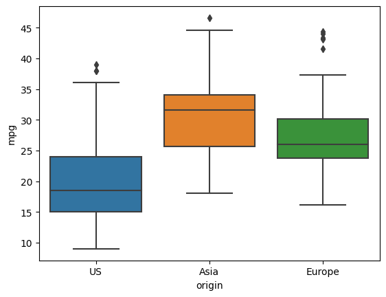

```python
# Create a boxplot of life expectancy per region
sns.boxplot(x='origin',y='mpg',data=df)

# Show the plot
plt.show()
```

En este caso haremos columnas dummies para la variable de "Origin", la cual contiene 3 posibles valores: US, Europe y Asia.

```python
# Creamos una dataframe que agregue las variables dummy de la columna origin
df_region= pd.get_dummies(df)
# Consultamos las columnas del dataframe original
print('Original: ')
print(df.columns)

# Consultamos las columnas del dataframe creado
print('Nuevo dataframe: ')
print(df_region.columns)
# Eliminamos una de las columnas creadas para las variables dummy
df_region= pd.get_dummies(df,drop_first=True)

# Consultamos las nuevas columnas
print('DF actuali=zado: ')
df_region.head()
```

```
Original:
Index(['mpg', 'displ', 'hp', 'weight', 'accel', 'origin', 'size'], dtype='object')
Nuevo dataframe:
Index(['mpg', 'displ', 'hp', 'weight', 'accel', 'size', 'origin_Asia',
       'origin_Europe', 'origin_US'],
      dtype='object')
DF actuali=zado:
```

|  | mpg | displ | hp | weight | accel | size | origin_Europe | origin_US |
| --- | --- | --- | --- | --- | --- | --- | --- | --- |
| 0 | 18.0 | 250.0 | 88 | 3139 | 14.5 | 15.0 | 0 | 1 |
| 1 | 9.0 | 304.0 | 193 | 4732 | 18.5 | 20.0 | 0 | 1 |
| 2 | 36.1 | 91.0 | 60 | 1800 | 16.4 | 10.0 | 0 | 0 |
| 3 | 18.5 | 250.0 | 98 | 3525 | 19.0 | 15.0 | 0 | 1 |
| 4 | 34.3 | 97.0 | 78 | 2188 | 15.8 | 10.0 | 1 | 0 |

Como se pudo ver el nuevo data frame contiene dos columnas adicionales Origin_Europe y origin_US, donde se indica si el auto proviene de un lugar u otro. Esta transformación nos permite crear un modelo predictivo, con las herramientas vistas en el capítulo anterior.

```python
#Importamos las librerias necesarias
from sklearn.linear_model import Ridge
from sklearn.linear_model import Lasso
from sklearn.model_selection import cross_val_score
import numpy as np
#Creamos las variables feature(X) y la variable target(y).
X=df_region[["hp", "weight"]].values
y=df_region["mpg"].values
#Creamos el modelo
ridge=Ridge(alpha=0.5)

#Evaluamos el modelo
ridge_cv= cross_val_score(ridge,X,y,cv=5)
print(ridge_cv)
#Imprimimos la media de los resultados de R2
print("El puntaje promedio de 5-fold cv: {}".format(np.mean(ridge_cv)))
```

```
[0.76616531 0.66118181 0.66338154 0.70728526 0.7192511 ]
El puntaje promedio de 5-fold cv: 0.7034530029090463
```

## 2-Manejo de Valores Faltantes

Para eliminar los valores nulos o faltantes, pandas ofrece una variedad de mÃ©todos que permiten transformarlos o eliminarlos por completo del conjunto de datos.

```python
### Cargamos el set de datos diabetes

diabetes=pd.read_csv('diabetes.csv')
diabetes.head()
```

|  | pregnancies | glucose | diastolic | triceps | insulin | bmi | dpf | age | diabetes |
| --- | --- | --- | --- | --- | --- | --- | --- | --- | --- |
| 0 | 6 | 148 | 72 | 35 | 0 | 33.6 | 0.627 | 50 | 1 |
| 1 | 1 | 85 | 66 | 29 | 0 | 26.6 | 0.351 | 31 | 0 |
| 2 | 8 | 183 | 64 | 0 | 0 | 23.3 | 0.672 | 32 | 1 |
| 3 | 1 | 89 | 66 | 23 | 94 | 28.1 | 0.167 | 21 | 0 |
| 4 | 0 | 137 | 40 | 35 | 168 | 43.1 | 2.288 | 33 | 1 |

```python
#Reemplazamos valores 0 con NA
diabetes.insulin.replace(0,np.nan,inplace=True)
diabetes.triceps.replace(0,np.nan,inplace=True)
diabetes.bmi.replace(0,np.nan,inplace=True)
diabetes.info()
```

```
<class 'pandas.core.frame.DataFrame'>
RangeIndex: 768 entries, 0 to 767
Data columns (total 9 columns):
 #   Column       Non-Null Count  Dtype
---  ------       --------------  -----
 0   pregnancies  768 non-null    int64
 1   glucose      768 non-null    int64
 2   diastolic    768 non-null    int64
 3   triceps      541 non-null    float64
 4   insulin      394 non-null    float64
 5   bmi          757 non-null    float64
 6   dpf          768 non-null    float64
 7   age          768 non-null    int64
 8   diabetes     768 non-null    int64
dtypes: float64(4), int64(5)
memory usage: 54.1 KB
```

Una forma es eliminando todos los valores que contengan al menos una columna en NA.

```python
#Creamos copias del dataframe para aplicarle distintos tratamientos
copia1=diabetes
copia2=diabetes
copia3=diabetes
#Eliminar registros con al menos un valor NA
copia1.dropna(axis=0)
```

|  | pregnancies | glucose | diastolic | triceps | insulin | bmi | dpf | age | diabetes |
| --- | --- | --- | --- | --- | --- | --- | --- | --- | --- |
| 3 | 1 | 89 | 66 | 23.0 | 94.0 | 28.1 | 0.167 | 21 | 0 |
| 4 | 0 | 137 | 40 | 35.0 | 168.0 | 43.1 | 2.288 | 33 | 1 |
| 6 | 3 | 78 | 50 | 32.0 | 88.0 | 31.0 | 0.248 | 26 | 1 |
| 8 | 2 | 197 | 70 | 45.0 | 543.0 | 30.5 | 0.158 | 53 | 1 |
| 13 | 1 | 189 | 60 | 23.0 | 846.0 | 30.1 | 0.398 | 59 | 1 |
| ... | ... | ... | ... | ... | ... | ... | ... | ... | ... |
| 753 | 0 | 181 | 88 | 44.0 | 510.0 | 43.3 | 0.222 | 26 | 1 |
| 755 | 1 | 128 | 88 | 39.0 | 110.0 | 36.5 | 1.057 | 37 | 1 |
| 760 | 2 | 88 | 58 | 26.0 | 16.0 | 28.4 | 0.766 | 22 | 0 |
| 763 | 10 | 101 | 76 | 48.0 | 180.0 | 32.9 | 0.171 | 63 | 0 |
| 765 | 5 | 121 | 72 | 23.0 | 112.0 | 26.2 | 0.245 | 30 | 0 |

393 rows Ã— 9 columns

Tambien podemos eliminar las columnas que contengan valores nulos.

```python
copia2.dropna(axis=1)
```

|  | pregnancies | glucose | diastolic | dpf | age | diabetes |
| --- | --- | --- | --- | --- | --- | --- |
| 0 | 6 | 148 | 72 | 0.627 | 50 | 1 |
| 1 | 1 | 85 | 66 | 0.351 | 31 | 0 |
| 2 | 8 | 183 | 64 | 0.672 | 32 | 1 |
| 3 | 1 | 89 | 66 | 0.167 | 21 | 0 |
| 4 | 0 | 137 | 40 | 2.288 | 33 | 1 |
| ... | ... | ... | ... | ... | ... | ... |
| 763 | 10 | 101 | 76 | 0.171 | 63 | 0 |
| 764 | 2 | 122 | 70 | 0.340 | 27 | 0 |
| 765 | 5 | 121 | 72 | 0.245 | 30 | 0 |
| 766 | 1 | 126 | 60 | 0.349 | 47 | 1 |
| 767 | 1 | 93 | 70 | 0.315 | 23 | 0 |

768 rows Ã— 6 columns

Otra sería eliminando únicamente aquellos que contienen NA en las columnas relevantes para el análisis.

```python
copia3.dropna(subset=["bmi"],axis=0)
```

|  | pregnancies | glucose | diastolic | triceps | insulin | bmi | dpf | age | diabetes |
| --- | --- | --- | --- | --- | --- | --- | --- | --- | --- |
| 0 | 6 | 148 | 72 | 35.0 | NaN | 33.6 | 0.627 | 50 | 1 |
| 1 | 1 | 85 | 66 | 29.0 | NaN | 26.6 | 0.351 | 31 | 0 |
| 2 | 8 | 183 | 64 | NaN | NaN | 23.3 | 0.672 | 32 | 1 |
| 3 | 1 | 89 | 66 | 23.0 | 94.0 | 28.1 | 0.167 | 21 | 0 |
| 4 | 0 | 137 | 40 | 35.0 | 168.0 | 43.1 | 2.288 | 33 | 1 |
| ... | ... | ... | ... | ... | ... | ... | ... | ... | ... |
| 763 | 10 | 101 | 76 | 48.0 | 180.0 | 32.9 | 0.171 | 63 | 0 |
| 764 | 2 | 122 | 70 | 27.0 | NaN | 36.8 | 0.340 | 27 | 0 |
| 765 | 5 | 121 | 72 | 23.0 | 112.0 | 26.2 | 0.245 | 30 | 0 |
| 766 | 1 | 126 | 60 | NaN | NaN | 30.1 | 0.349 | 47 | 1 |
| 767 | 1 | 93 | 70 | 31.0 | NaN | 30.4 | 0.315 | 23 | 0 |

757 rows Ã— 9 columns

Pero existen otras estrategias para tratar los valores faltantes:**Imputing**

```python
## Cargamos las librerias
from sklearn.impute import SimpleImputer
from sklearn.pipeline import Pipeline
from sklearn.linear_model import LinearRegression
from sklearn.model_selection import train_test_split

#Se crea el Imputer, donde se establecen los valores que desean cambiarse y la estrategia que se utilizarÃ¡
imp= SimpleImputer(missing_values=np.nan, strategy ='mean')

#Se crea un nuevo data frame con la informaciÃ³n completa
idf=pd.DataFrame(imp.fit_transform(diabetes))

#Colocamos las columnas y el index
idf.columns=diabetes.columns
idf.index=diabetes.index

idf.head()
```

|  | pregnancies | glucose | diastolic | triceps | insulin | bmi | dpf | age | diabetes |
| --- | --- | --- | --- | --- | --- | --- | --- | --- | --- |
| 0 | 6.0 | 148.0 | 72.0 | 35.00000 | 155.548223 | 33.6 | 0.627 | 50.0 | 1.0 |
| 1 | 1.0 | 85.0 | 66.0 | 29.00000 | 155.548223 | 26.6 | 0.351 | 31.0 | 0.0 |
| 2 | 8.0 | 183.0 | 64.0 | 29.15342 | 155.548223 | 23.3 | 0.672 | 32.0 | 1.0 |
| 3 | 1.0 | 89.0 | 66.0 | 23.00000 | 94.000000 | 28.1 | 0.167 | 21.0 | 0.0 |
| 4 | 0.0 | 137.0 | 40.0 | 35.00000 | 168.000000 | 43.1 | 2.288 | 33.0 | 1.0 |

## Escalamiento de Datos

En algunas ocasiones puede ser necesario escalar o normalizar ciertos datos, debido a que se encuentra en un rango muy amplío o aumentan la complejidad de nuestro modelo y análisis ya que son difíciles de entender. Para esto se puede utilizar el paquete **scale** de scikitlearn. Como resultado nos brindará un conjunto de datos con una menor variabilidad.

```
Valores sin escalamiento:
Media de los valores: 120.89453125
Desviacion estandar: 31.95179590820272
```

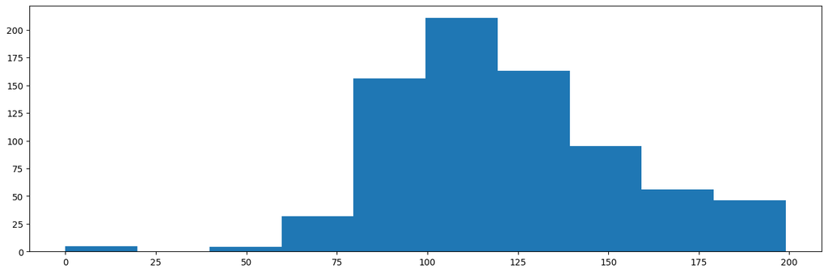

```python
from sklearn.preprocessing import scale

X= idf.glucose.values
# Consultamos datos estadÃsticos del conjunto original
print("Valores sin escalamiento: ")
print("Media de los valores: {}".format(np.mean(X)))
print("Desviacion estandar: {}".format(np.std(X)))
plt.figure(figsize=(16,5))
plt.hist(X)
plt.show()
```

```
Valores sin escalamiento:
Desviacion estandar: 1.0
```

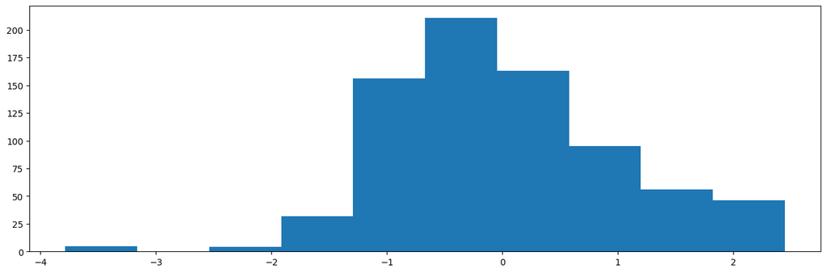

```python
#Escalamos el valor
X_scaled=scale(X)
# Consultamos datos estadÃsticos del nuevo conjunto
print("Valores sin escalamiento: ")
print("Desviacion estandar: {}".format(np.std(X_scaled)))
## Visualizamos los resultados
plt.figure(figsize=(16,5))
plt.hist(X_scaled)
plt.show()
```

### Pipeline

Forma parte del paquete Scikit learn, permite automatizar las tareas de procesamiento de datos para la creación de proyectos de Machine Learning. Pipeline nos permite crear flujos de trabajo, donde podemos aplicar transformaciones, crear modelos y posteriormente crear predicciones. También se pueden utilizar en conjunto con otras clases como GridSearchCV para seleccionar parámetros e hiperparámetros de los modelos mediante validación cruzada.

#### Ejercicio #1: Pipeline Modelo de Regresión con Autos

```python
## Importamos los paquetes
import pandas as pd
from sklearn.linear_model import Ridge
import matplotlib.pyplot as plt
import numpy as np
from sklearn.preprocessing import StandardScaler

#Importamos el dataset
df= pd.read_csv('autos.csv')
df_region=pd.get_dummies(df)

#Definimos los pasos que tendrÃ¡ el Pipeline
steps=[('scaler',StandardScaler()),('ridge',Ridge(alpha=0.5))]

#Asignamos los pasos a el Pipeline
pipeline=Pipeline(steps)
#Creamos las variables X y Y
X=df_region[["hp", "weight"]].values
y=df_region["mpg"].values
#Dividimos el conjunto en datos de testing y training
X_train, X_test, y_train, y_test = train_test_split(X, y, test_size=0.2, random_state=21)

#Entrenamos el modelo
ridge_scaled=pipeline.fit(X_train,y_train)

#Evaluamos el rendimiento
print(ridge_scaled.score(X_test,y_test))
```

```
0.7107232787779652
```

```python
## Importamos los paquetes
import pandas as pd
from sklearn.linear_model import Ridge
import matplotlib.pyplot as plt
import numpy as np
from sklearn.preprocessing import StandardScaler
from sklearn.pipeline import Pipeline
from sklearn.decomposition import PCA
from sklearn.model_selection import GridSearchCV
from sklearn.datasets import load_diabetes

#ImportaciÃ³n del dataset
diabetes= load_diabetes()
diabetes
```

[output not shown]

[output cut: 14 more lines]

[output not shown]

```python
#CreaciÃ³n de variables X y Y
X= diabetes.data
y=diabetes.target

#Creamos la tuberÃa o Pipeline, con cada una de las transformaciones
pipeline=Pipeline([('Scale',StandardScaler()),('pca',PCA(n_components=2)),('model',Lasso(alpha=0.1))])

#Entrenamos
pipeline.fit(X,y)

#Definimos los parÃ¡metros a probar
components=[1,2,3,4,5,6]
alpha=[1,0.5,0.2,0.1,0.05,0.02,0.01]
#Creamos el objeto GridSearchCV

grid= GridSearchCV(estimator=pipeline,param_grid=dict(pca__n_components=components,model__alpha=alpha),cv=3)
#Entreamos
grid.fit(X,y)

#Obtenemos los parÃ¡metros con mejor rendimiento
grid.best_params_
```

```
{'model__alpha': 0.5, 'pca__n_components': 6}
```

#### Ejercicio 3: Modelos de Regresión ElasticNet

```python
## Importamos los paquetes
import pandas as pd
from sklearn.linear_model import Ridge
import matplotlib.pyplot as plt
import numpy as np
from sklearn.preprocessing import StandardScaler
from sklearn.pipeline import Pipeline
from sklearn.decomposition import PCA
from sklearn.model_selection import GridSearchCV
from sklearn.datasets import load_diabetes
from sklearn.impute import SimpleImputer
from sklearn.linear_model import ElasticNet
from sklearn.model_selection import RepeatedKFold
from sklearn.model_selection import train_test_split

## Cargamos el Dataframe
diabetes= load_diabetes()

X, y = diabetes.data, diabetes.target

# Definimos los pasos para el Pipeline
steps=[('imputation', SimpleImputer(missing_values=np.nan, strategy='mean')),
       ('scaler', StandardScaler()),
       ('elasticnet', ElasticNet())]

# Creamos el pipeline
pipeline = Pipeline(steps)

# Definimos los parametros
parameters = {'elasticnet__l1_ratio': np.linspace(0, 1, 30), 'elasticnet__alpha': np.array([1.0, 10.0, 100.0])}
cv = RepeatedKFold(n_splits=10, n_repeats=3, random_state=1)

# Creamos los conjuntos de training y testing
X_train, X_test, y_train, y_test = train_test_split(X, y, test_size=0.3)

# Creamos el conjunto GridSearchCV y agregamos los parametros
gm_cv = GridSearchCV(pipeline, param_grid=parameters, scoring='r2', cv=cv, n_jobs=-1)

# Entramos el modelo
gm_cv.fit(X_train, y_train)

# Compute and print the metrics
r2 = gm_cv.score(X_test, y_test)
print("Elastic Alpha: {}".format(gm_cv.best_params_))
print("ElasticNet R Cuadrado: {}".format(r2))
```

```
Elastic Alpha: {'elasticnet__alpha': 1.0, 'elasticnet__l1_ratio': 1.0}
ElasticNet R Cuadrado: 0.4430275175403783
```